# Same-Day Release Policies by Patient Population

Exploratory four-policy comparison using the existing 840 simulation backgrounds

## Research question

Under which patient-population conditions do the following policies improve average appointment utilization?

| Policy | Booking horizon | Same-day-release reservations |
| --- | --- | --- |
| Baseline | Native horizon | None |
| Horizon only | Optimized | None |
| Reservation only | Native horizon | Quantity and window optimized |
| Both flexible | Horizon, quantity, and window jointly optimized |  |

The main outcome is:

> **Average utilization** = **completed appointments** ÷ **available measured appointment slots**

A difference smaller than **0.005 average utilization** is treated as practically equivalent. Policies that fall within 0.005 of the best result for a background are therefore reported as tied for best rather than forced into a single ranking.

## Patient characteristics

This Phase 1 analysis uses the existing heterogeneous simulation bank. It identifies backgrounds matching five clinically interpretable Class 1 characteristics:

| Patient characteristic | Phase 1 definition | Policy interaction being tested |
| --- | --- | --- |
| Class 1 more no-show sensitive | Lower no-show threshold, with pre- and post-threshold no-show probabilities at least as high as Class 2 | Whether shorter horizons, near-term reservations, or both reduce delay-related no-shows |
| Class 1 more balking sensitive | Lower balking threshold, with pre- and post-threshold balking probabilities at least as high as Class 2 | Whether the policies make acceptable near-term appointments more available |
| Class 1 more cancellation prone | Class 1 cancellation probability is higher than Class 2 | Whether day-of release prevents unused Class 1 reservations from lowering utilization |
| Priority-group share | Class 1 share analysed at 0.1, 0.3, 0.5, 0.7 and 0.9 | Whether the value and appropriate size of reservations depend on the size of Class 1 |
| Class 1 jointly delay sensitive | Class 1 satisfies both the no-show-sensitive and balking-sensitive definitions | Whether combining horizon flexibility and reservations is especially valuable when both delay responses are elevated |

These are exploratory associations. In the existing bank, non-target patient behaviours were not held equal between the classes. The later targeted simulations will use controlled same, mild and strong Class 1 contrasts.

## Simulation coverage

| Patient characteristic | Characteristic level | Backgrounds |
| --- | --- | --- |
| Class 1 more no-show sensitive | Main definition | 137 |
| Class 1 more balking sensitive | Main definition | 145 |
| Class 1 more cancellation prone | Class 1 cancellation > Class 2 | 261 |
| Priority-group share | 10% | 172 |
| Priority-group share | 30% | 150 |
| Priority-group share | 50% | 181 |
| Priority-group share | 70% | 154 |
| Priority-group share | 90% | 183 |
| Class 1 jointly delay sensitive | No-show and balking sensitive | 42 |

## Phase 1 findings

The existing simulations provide exploratory evidence rather than controlled characteristic effects. Non-target patient behaviours can still differ between Class 1 and Class 2 within these subsets.

Both-flexible searches over a policy space that includes the horizon-only and reservation-only choices. Its selected point estimate therefore cannot be worse than those nested alternatives. The meaningful question is whether its additional gain exceeds **0.005** and is confidence supported.

Table 1: Four-policy summary within the four behaviour-defined patient profiles.

| Patient characteristic | Policy | Backgrounds | Mean difference from baseline | Median difference from baseline | Practically tied for best |
| --- | --- | --- | --- | --- | --- |
| Class 1 more no-show sensitive | Baseline | 137 | 0.00 pp | 0.00 pp | 85.4% |
| Class 1 more no-show sensitive | Horizon only | 137 | 0.52 pp | 0.00 pp | 97.8% |
| Class 1 more no-show sensitive | Reservation only | 137 | 0.26 pp | 0.11 pp | 94.9% |
| Class 1 more no-show sensitive | Both flexible | 137 | 0.66 pp | 0.16 pp | 100.0% |
| Class 1 more balking sensitive | Baseline | 145 | 0.00 pp | 0.00 pp | 73.1% |
| Class 1 more balking sensitive | Horizon only | 145 | 0.80 pp | 0.00 pp | 81.4% |
| Class 1 more balking sensitive | Reservation only | 145 | 0.76 pp | 0.17 pp | 92.4% |
| Class 1 more balking sensitive | Both flexible | 145 | 1.34 pp | 0.26 pp | 100.0% |
| Class 1 more cancellation prone | Baseline | 261 | 0.00 pp | 0.00 pp | 72.0% |
| Class 1 more cancellation prone | Horizon only | 261 | 0.63 pp | 0.00 pp | 83.5% |
| Class 1 more cancellation prone | Reservation only | 261 | 0.92 pp | 0.19 pp | 95.4% |
| Class 1 more cancellation prone | Both flexible | 261 | 1.06 pp | 0.25 pp | 100.0% |
| Class 1 jointly delay sensitive | Baseline | 42 | 0.00 pp | 0.00 pp | 83.3% |
| Class 1 jointly delay sensitive | Horizon only | 42 | 0.59 pp | 0.00 pp | 97.6% |
| Class 1 jointly delay sensitive | Reservation only | 42 | 0.35 pp | 0.14 pp | 90.5% |
| Class 1 jointly delay sensitive | Both flexible | 42 | 0.74 pp | 0.16 pp | 100.0% |

Table 2: Paired classification of each active policy versus baseline.

| Patient characteristic | Policy | Supported increase | Practical tie | Supported decrease | Uncertain increase |
| --- | --- | --- | --- | --- | --- |
| Class 1 more no-show sensitive | Horizon only | 14 | 123 | 0 | 0 |
| Class 1 more no-show sensitive | Reservation only | 10 | 126 | 0 | 1 |
| Class 1 more no-show sensitive | Both flexible | 19 | 117 | 0 | 1 |
| Class 1 more balking sensitive | Horizon only | 19 | 126 | 0 | 0 |
| Class 1 more balking sensitive | Reservation only | 32 | 113 | 0 | 0 |
| Class 1 more balking sensitive | Both flexible | 39 | 106 | 0 | 0 |
| Class 1 more cancellation prone | Horizon only | 42 | 219 | 0 | 0 |
| Class 1 more cancellation prone | Reservation only | 59 | 200 | 0 | 2 |
| Class 1 more cancellation prone | Both flexible | 70 | 188 | 0 | 3 |
| Class 1 jointly delay sensitive | Horizon only | 5 | 37 | 0 | 0 |
| Class 1 jointly delay sensitive | Reservation only | 3 | 39 | 0 | 0 |
| Class 1 jointly delay sensitive | Both flexible | 7 | 35 | 0 | 0 |

The mean differences are consistently larger than the medians because a minority of backgrounds produce comparatively large gains. Most comparisons remain practically tied.

## All four policies side by side

The first figure keeps all four policies in one comparison. Each point is the median within-background utilization difference from baseline; thick intervals show the interquartile range across backgrounds.

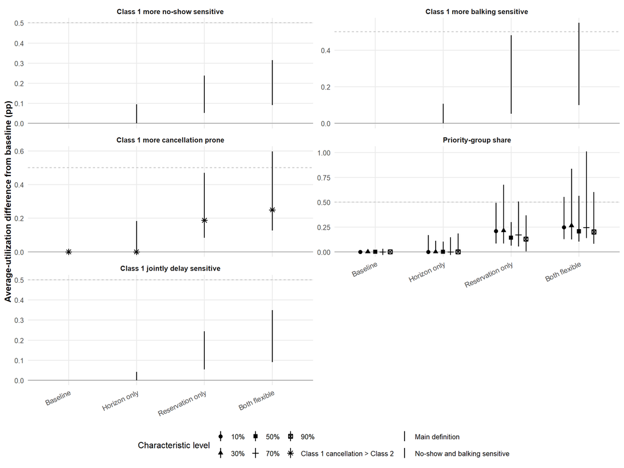

Figure 1: All four policies compared within each patient characteristic. Baseline is zero by construction. Points show median utilization differences from baseline; intervals show the interquartile range across backgrounds.

This is a descriptive comparison of the four selected policies. Confidence-supported claims between specific policies can still use the paired bootstrap results, but the report does not organise the presentation as six separate pairwise analyses.

## Which policies are practically tied for best?

A policy is counted as practically best when its average utilization is no more than 0.005 below the highest-utilization policy in that background. Multiple policies can be counted in the same background.

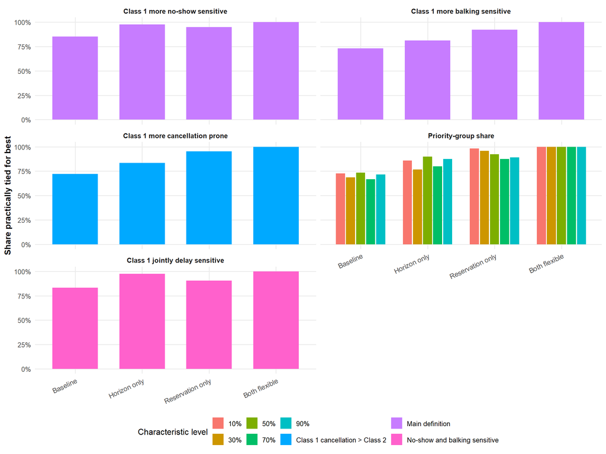

Figure 2: Share of backgrounds in which each policy is within 0.005 average utilization of the best policy. Percentages may sum to more than 100% because practical ties are retained.

## How demand and priority-group share change the comparison

The following heatmap presents all four policies together. Baseline remains the zero reference. Values are grouped medians over the remaining heterogeneous parameters.

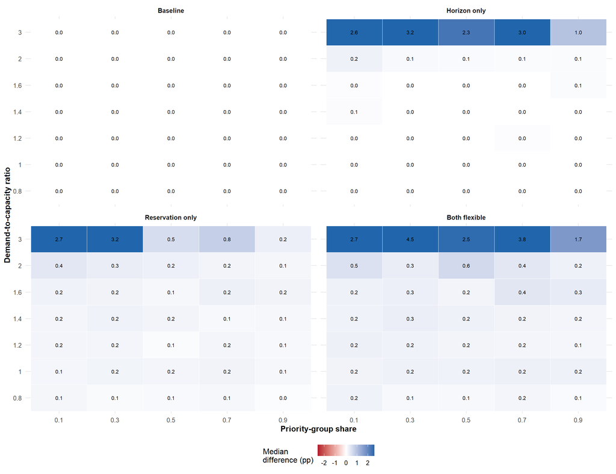

Figure 3: Median average-utilization difference from baseline by demand-to-capacity ratio, priority-group share and policy. Each cell aggregates over the remaining scenario parameters.

## Results by patient characteristic

### Class 1 more no-show sensitive

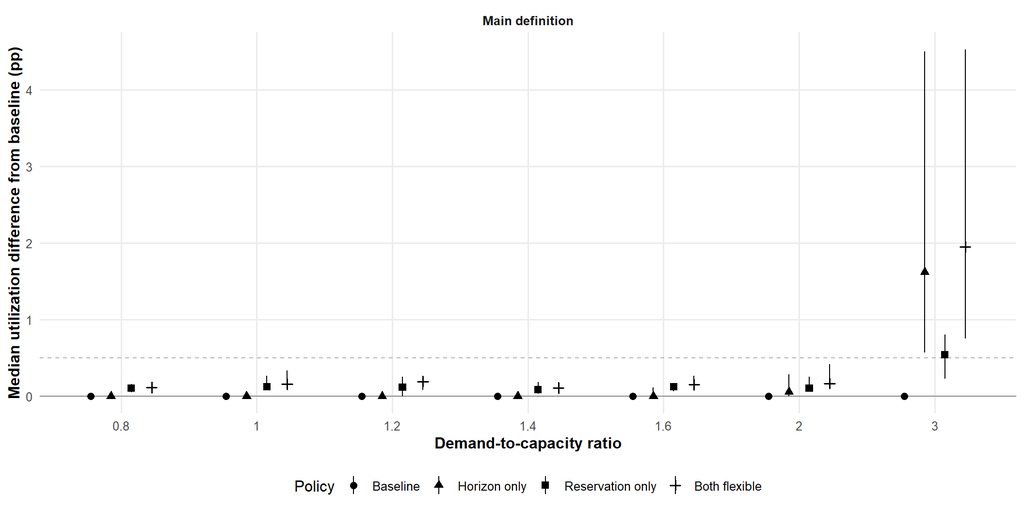

Figure 4: Four-policy comparison when Class 1 has a lower no-show threshold and no-show probabilities at least as high as Class 2.

**Interpretation.** Horizon only had a larger mean gain than reservation only (**0.52 pp versus 0.26 pp**). Both-flexible and horizon only were practically tied in **134 of 137** backgrounds. The current evidence therefore suggests that shortening the horizon usually addresses this profile’s main delay-related mechanism without requiring protected slots.

### Class 1 more balking sensitive

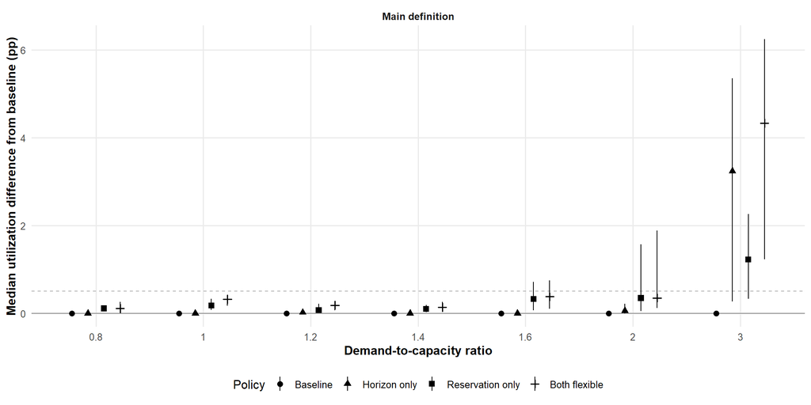

Figure 5: Four-policy comparison when Class 1 has a lower balking threshold and balking probabilities at least as high as Class 2.

**Interpretation.** Reservations showed the clearest exploratory interaction with balking sensitivity. Both-flexible produced a supported increase over baseline in **39 of 145** backgrounds, reservation only in **32**, and horizon only in **19**. Reservation only was sometimes better and sometimes worse than horizon only, showing that demand and patient composition still determine which mechanism matters more.

### Class 1 more cancellation prone

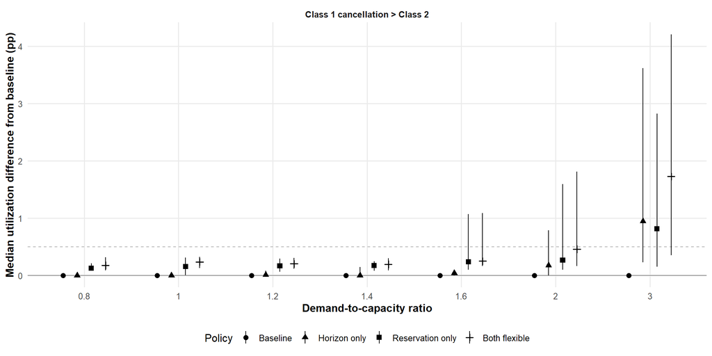

Figure 6: Four-policy comparison when Class 1 has a higher cancellation probability than Class 2.

**Interpretation.** Higher Class 1 cancellation did not create a general utilization penalty for reservations under day-of release. Reservation only had a larger mean gain than horizon only (**0.92 pp versus 0.63 pp**), while both-flexible and reservation only were practically tied in **249 of 261** backgrounds. Same-day release appears to remove much of the unused-capacity cost, although Class 2 can still lose advance access.

### Priority-group share

The share analysis uses the same four-policy outcomes but treats each tested Class 1 share as a separate patient-composition level.

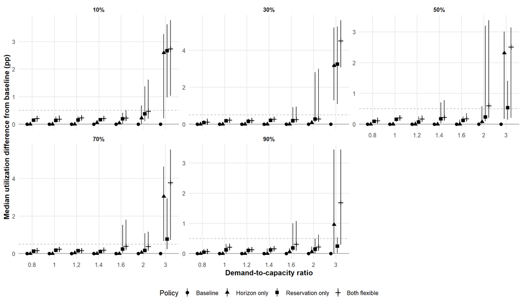

Figure 7: Four-policy comparison by Class 1 share and demand-to-capacity ratio.

**Interpretation.** Reservation value was highest on average at a **0.3 Class 1 share** and lowest at **0.9**. A very large Class 1 population already occupies much of the general pool, reducing the incremental value of explicit protection. The relationship is not monotone, so share should be analysed jointly with demand and the selected reservation quantity.

### Class 1 jointly delay sensitive

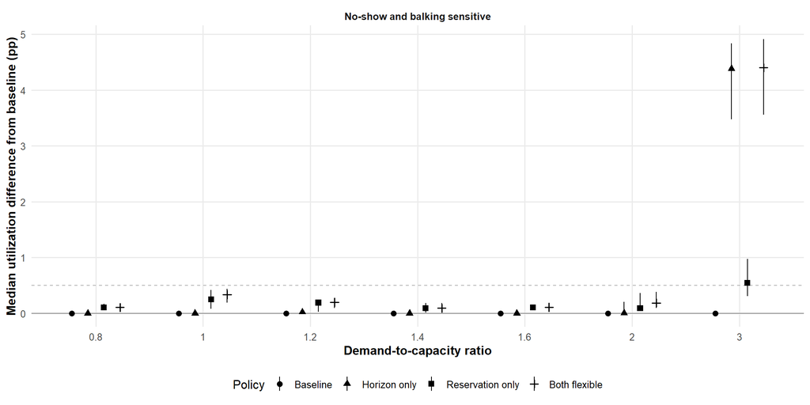

Figure 8: Four-policy comparison when Class 1 is both more no-show sensitive and more balking sensitive than Class 2.

**Interpretation.** The joint profile did not produce a strong additional benefit from combining the policies: both-flexible and horizon only were practically tied in **41 of 42** backgrounds. This subgroup is small and heterogeneous, and the strict joint definition contains only nine backgrounds.

## Effects on Class 1 and Class 2

The main policy presentation compares all four policies together. Patient-group confidence classifications remain relative to baseline because a gain or loss must be defined against a reference policy.

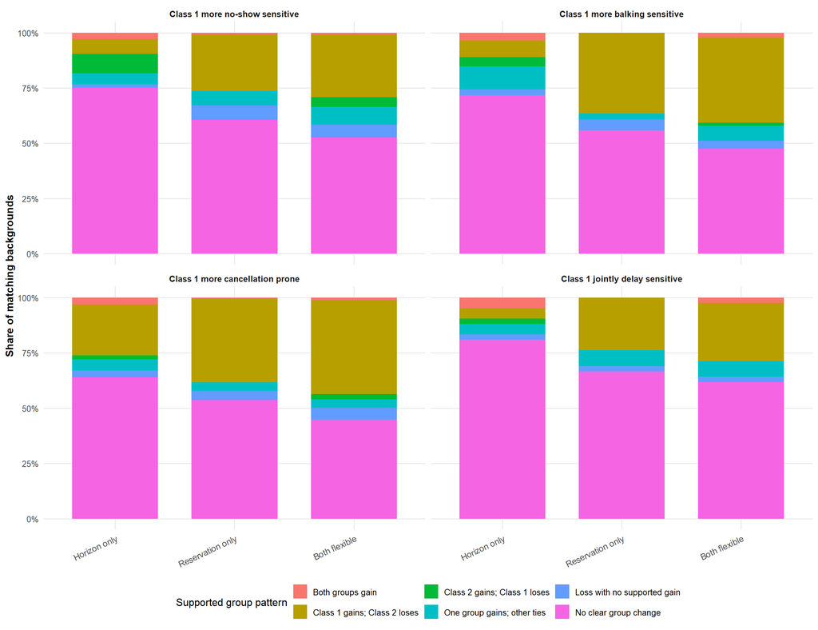

Figure 9: Confidence-supported Class 1 and Class 2 served-rate patterns for each active policy compared with baseline, shown by patient characteristic.

“Loss with no supported gain” combines:

- Class 1 loses while Class 2 ties;
- Class 2 loses while Class 1 ties; and
- both groups lose.

It excludes the two explicit gain-loss trade-off categories.

Reservation-based policies frequently improve Class 1 served rate while reducing Class 2 served rate. An aggregate utilization gain should therefore not be interpreted as a gain shared by both populations.

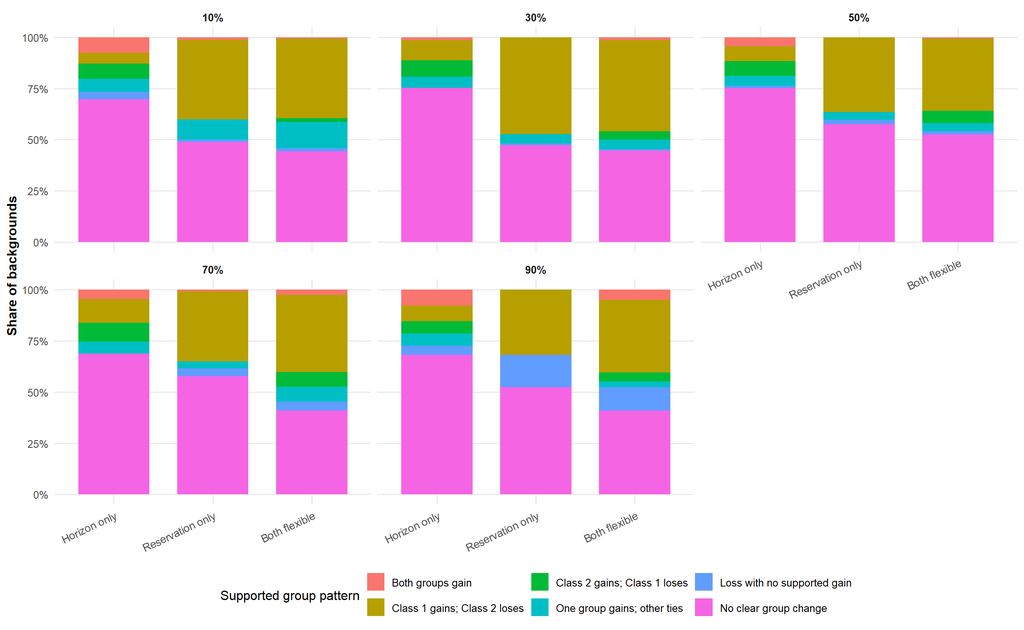

Figure 10: Confidence-supported Class 1 and Class 2 served-rate patterns by priority-group share.

## Selected policy design

(Q) is the number of slots per service day reserved for Class 1 during the reservation window. Under same-day release, unused Class 1 reservations return to the pooled appointment capacity on the service day.

The booking horizon was selected from the discrete candidate grid **2, 6, 10, 14, 18, 22 and 26 days**. Intermediate values were not tested. Baseline and reservation only retain the native scenario horizon, so the optimized-horizon figure includes only horizon only and both-flexible.

### Booking-horizon selections

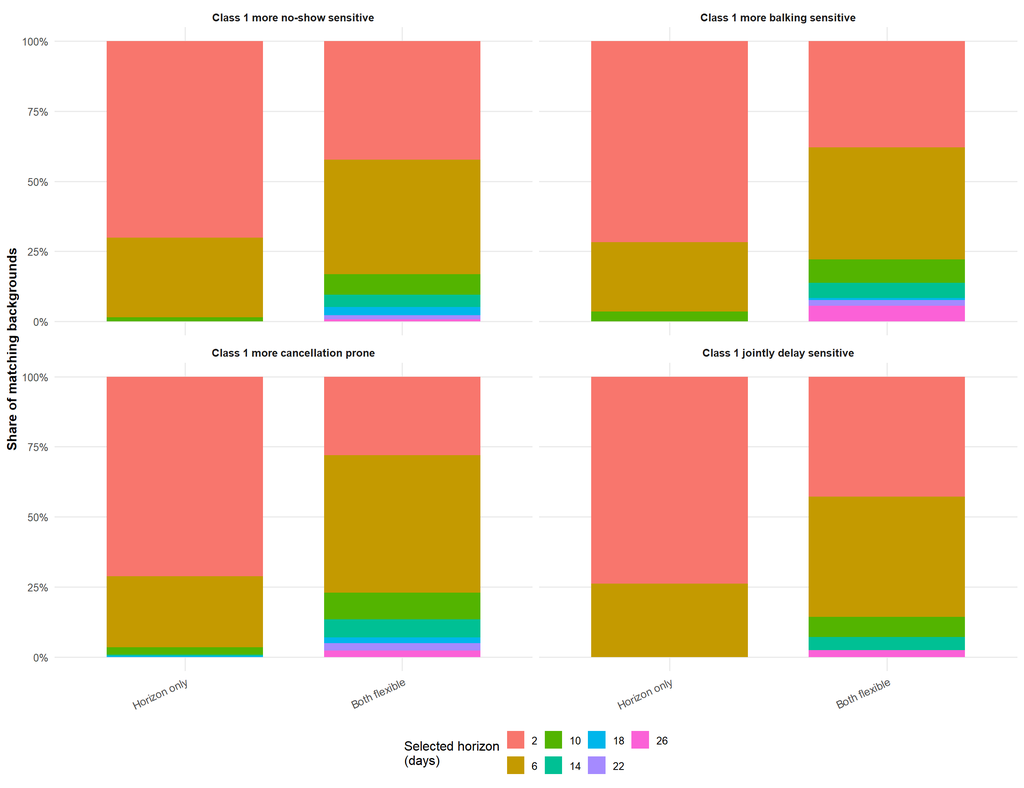

Figure 11: Distribution of selected booking horizons by policy and patient characteristic. The horizon is categorical because only seven values were tested.

### Reservation quantity and window

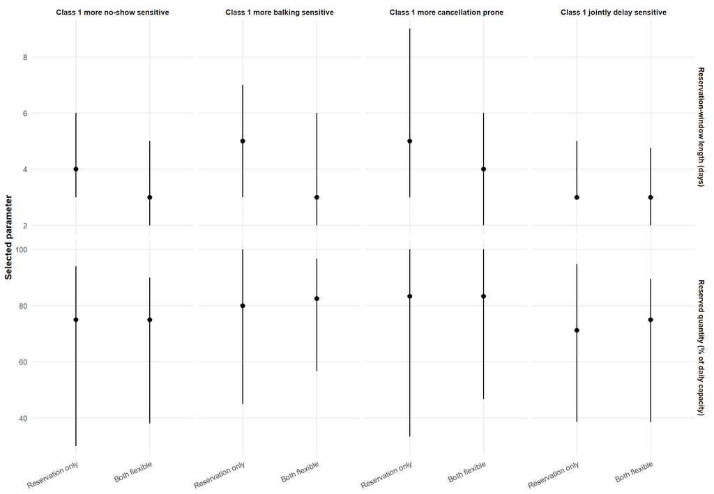

Figure 12: Selected reservation quantity and reservation-window length for reservation-only and both-flexible policies. Points show medians and intervals show interquartile ranges.

## Strict-definition sensitivity check

The main no-show and balking definitions allow one or both probabilities to tie with Class 2. The strict definitions require both probabilities to be higher.

| Definition | Backgrounds |
| --- | --- |
| No-show sensitive: main | 137 |
| No-show sensitive: strict | 52 |
| Balking sensitive: main | 145 |
| Balking sensitive: strict | 53 |
| Jointly sensitive: main | 42 |
| Jointly sensitive: strict | 9 |

The strict subsets should be used as a robustness check rather than as the main analysis if their sample sizes are too small for stable scenario-level summaries.

The strict no-show and balking subsets preserve the broad direction of the main exploratory results. The strict joint subset contains only nine backgrounds and is too small for a stable general conclusion.

## Interpretation for the next simulation stage

The existing results identify the most useful controlled pilot comparisons:

1. **No-show sensitivity:** test whether horizon only remains sufficient when the no-show contrast is isolated from balking and cancellation differences.
2. **Balking sensitivity:** compare reservation only and both-flexible most closely because reservations showed the clearest exploratory interaction.
3. **Cancellation propensity:** verify that day-of release continues to protect utilization when Class 1 cancellations are systematically higher.
4. **Priority-group share:** preserve the full 0.1–0.9 range because reservation value was not monotone.
5. **Joint delay sensitivity:** include same, mild and strong contrasts, but do not infer the expected result from the small current subgroup.

For each targeted profile, the new scenario bank should:

- use two Class 2 reference profiles;
- set Class 1 to the same, mildly more sensitive or strongly more sensitive level;
- hold non-target behaviours equal between classes within a background;
- vary clinic-level demand, capacity, native horizon and Class 1 share;
- evaluate all four policies with paired seeds; and
- use same-day-release reservations only.

The targeted simulation results should eventually replace causal-sounding interpretations while retaining the same four-policy visual structure.